# Situación problema (parte 1)

Modelo de regresión

Carlos Ito, Juan Pablo Escobar, Fernanda Gómez, Antonio Marban

MA1031: Análisis estadístico

# 1 Situación problema: Los factores de impacto y su relación con la eficiencia de sueño

Se quiere predecir la eficiencia de sueño de una persona en función de diversas variables.

# 2 Conociendo nuestras variables

```r
datos<-na.omit(read.csv("Sleep_Efficiency.csv",header = TRUE))
attach(datos)
head(datos)
```

```
##   ID Age Gender        Bedtime   Wakeup.time Sleep.duration Sleep.efficiency
## 1  1  65 Female  06/03/21 1:00 06/03/21 7:00              6             0.88
## 2  2  69   Male  05/12/21 2:00 05/12/21 9:00              7             0.66
## 3  3  40 Female 25/05/21 21:30 25/05/21 5:30              8             0.89
## 4  4  40 Female  03/11/21 2:30 03/11/21 8:30              6             0.51
## 5  5  57   Male  13/03/21 1:00 13/03/21 9:00              8             0.76
## 7  7  27 Female 21/07/21 21:00 21/07/21 3:00              6             0.54
##   REM.sleep.percentage Deep.sleep.percentage Light.sleep.percentage Awakenings
## 1                   18                    70                     12          0
## 2                   19                    28                     53          3
## 3                   20                    70                     10          1
## 4                   23                    25                     52          3
## 5                   27                    55                     18          3
## 7                   28                    25                     47          2
##   Caffeine.consumption Alcohol.consumption Smoking.status Exercise.frequency
## 1                    0                   0            Yes                  3
## 2                    0                   3            Yes                  3
## 3                    0                   0             No                  3
## 4                   50                   5            Yes                  1
## 5                    0                   3             No                  3
## 7                   50                   0            Yes                  1
```

Podemos ver los nombres de nuestras variables, así como los tipos de datos que las componen.

```r
str(datos)
```

```
## 'data.frame':    388 obs. of  15 variables:
##  $ ID                    : int  1 2 3 4 5 7 8 9 10 11 ...
##  $ Age                   : int  65 69 40 40 57 27 53 41 11 50 ...
##  $ Gender                : chr  "Female" "Male" "Female" "Female" ...
##  $ Bedtime               : chr  "06/03/21 1:00" "05/12/21 2:00" "25/05/21 21:30" "03/11/21 2:30" ...
##  $ Wakeup.time           : chr  "06/03/21 7:00" "05/12/21 9:00" "25/05/21 5:30" "03/11/21 8:30" ...
##  $ Sleep.duration        : num  6 7 8 6 8 6 10 6 9 8 ...
##  $ Sleep.efficiency      : num  0.88 0.66 0.89 0.51 0.76 0.54 0.9 0.79 0.55 0.92 ...
##  $ REM.sleep.percentage  : int  18 19 20 23 27 28 28 28 18 23 ...
##  $ Deep.sleep.percentage : int  70 28 70 25 55 25 52 55 37 57 ...
##  $ Light.sleep.percentage: int  12 53 10 52 18 47 20 17 45 20 ...
##  $ Awakenings            : int  0 3 1 3 3 2 0 3 4 1 ...
##  $ Caffeine.consumption  : int  0 0 0 50 0 50 50 50 0 50 ...
##  $ Alcohol.consumption   : int  0 3 0 5 3 0 0 0 0 0 ...
##  $ Smoking.status        : chr  "Yes" "Yes" "No" "Yes" ...
##  $ Exercise.frequency    : int  3 3 3 1 3 1 3 1 0 3 ...
##  - attr(*, "na.action")= 'omit' Named int [1:64] 6 20 21 25 27 34 38 58 61 63 ...
##   ..- attr(*, "names")= chr [1:64] "6" "20" "21" "25" ...
```

# 3 Estadística descriptiva

Hacemos la estadística descriptiva para analizar y resumir datos de manera que podamos comprender mejor las características fundamentales de nuestro conjunto de datos. Mediante el uso de los cuartiles, podemos obtener información clave sobre la distribución, la tendencia central, la dispersión y la presencia de valores atípicos en los datos.

```r
summary(datos)
```

```
##        ID             Age           Gender            Bedtime
##  Min.   :  1.0   Min.   : 9.00   Length:388         Length:388
##  1st Qu.:111.8   1st Qu.:29.00   Class :character   Class :character
##  Median :228.5   Median :41.00   Mode  :character   Mode  :character
##  Mean   :226.3   Mean   :40.83
##  3rd Qu.:339.2   3rd Qu.:52.00
##  Max.   :452.0   Max.   :69.00
##  Wakeup.time        Sleep.duration   Sleep.efficiency REM.sleep.percentage
##  Length:388         Min.   : 5.000   Min.   :0.5000   Min.   :15.00
##  Class :character   1st Qu.: 7.000   1st Qu.:0.7000   1st Qu.:20.00
##  Mode  :character   Median : 7.500   Median :0.8200   Median :22.00
##                     Mean   : 7.451   Mean   :0.7893   Mean   :22.68
##                     3rd Qu.: 8.000   3rd Qu.:0.9000   3rd Qu.:25.00
##                     Max.   :10.000   Max.   :0.9900   Max.   :30.00
##  Deep.sleep.percentage Light.sleep.percentage   Awakenings
##  Min.   :18.00         Min.   : 7.0           Min.   :0.000
##  1st Qu.:51.00         1st Qu.:15.0           1st Qu.:1.000
##  Median :58.00         Median :18.0           Median :1.000
##  Mean   :52.82         Mean   :24.5           Mean   :1.619
##  3rd Qu.:63.00         3rd Qu.:24.0           3rd Qu.:3.000
##  Max.   :75.00         Max.   :63.0           Max.   :4.000
##  Caffeine.consumption Alcohol.consumption Smoking.status     Exercise.frequency
##  Min.   :  0.00       Min.   :0.000       Length:388         Min.   :0.000
##  1st Qu.:  0.00       1st Qu.:0.000       Class :character   1st Qu.:0.000
##  Median :  0.00       Median :0.000       Mode  :character   Median :2.000
##  Mean   : 22.68       Mean   :1.147                          Mean   :1.758
##  3rd Qu.: 50.00       3rd Qu.:2.000                          3rd Qu.:3.000
##  Max.   :200.00       Max.   :5.000                          Max.   :5.000
```

## 3.1 Graficas descriptivas

Para visualizar estos datos descriptivos utilizamos diagramas de caja y bigotes.

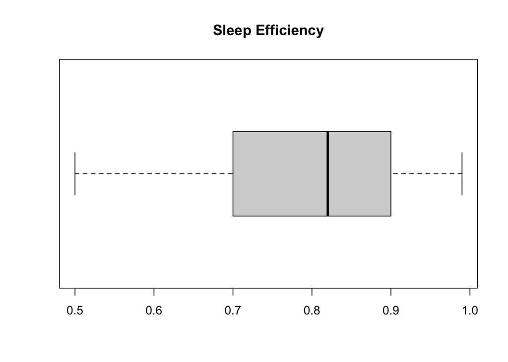

```r
cuanti<- cbind(Sleep.efficiency,Age,Sleep.duration,Awakenings,Caffeine.consumption,Alcohol.consumption,Exercise.frequency)

boxplot(cuanti[,1], horizontal = T, main="Sleep Efficiency")  # grafica la primera variable de ese arreglo
```

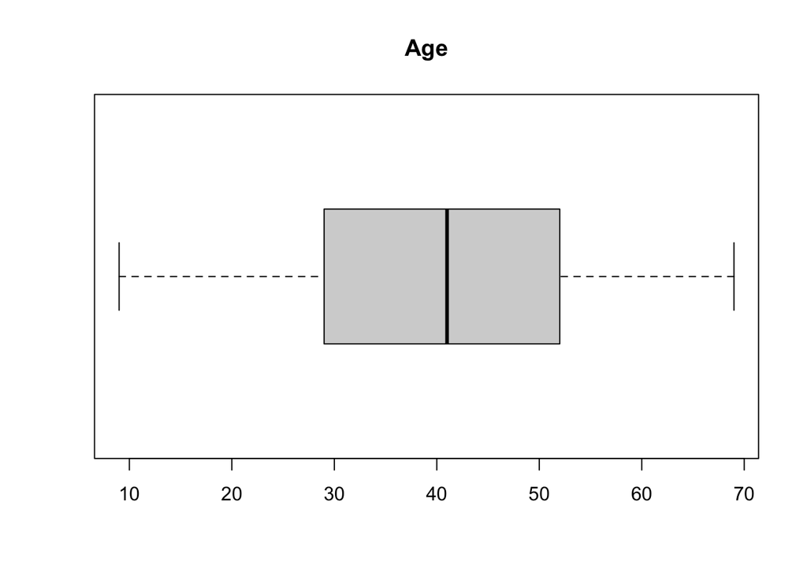

```r
boxplot(cuanti[,2], horizontal = T, main="Age")
```

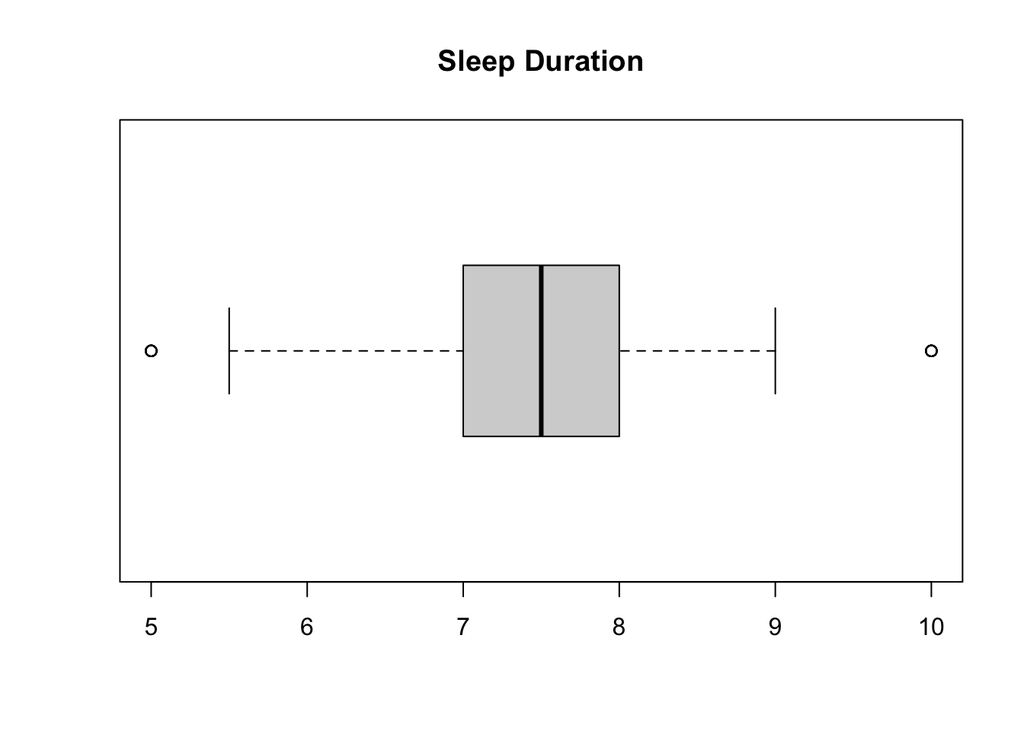

```r
boxplot(cuanti[,3], horizontal = T, main="Sleep Duration")
```

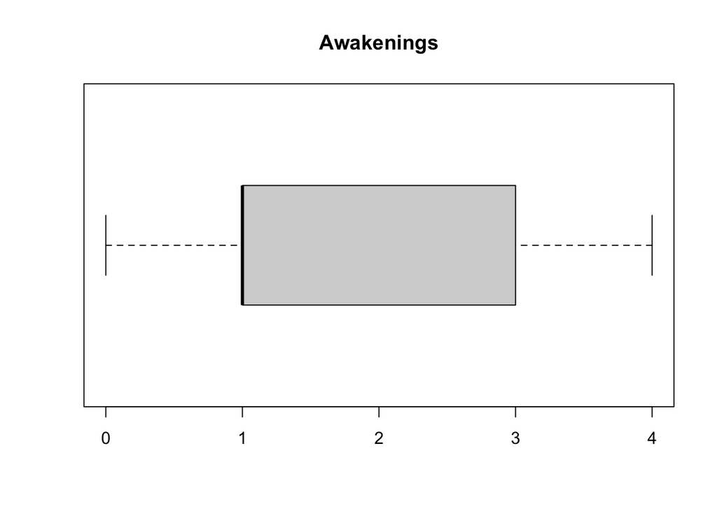

```r
boxplot(cuanti[,4], horizontal = T, main="Awakenings")
```

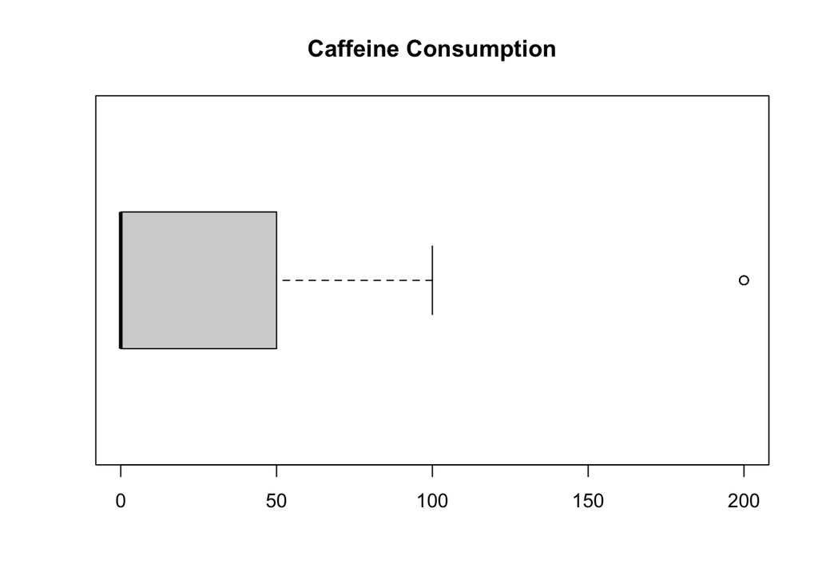

```r
boxplot(cuanti[,5], horizontal = T, main="Caffeine Consumption")  # grafica la primera variable de ese arreglo
```

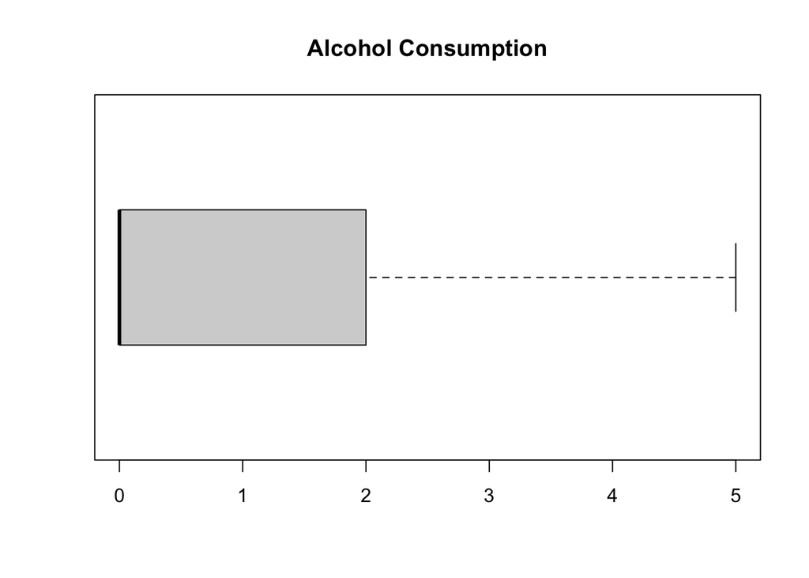

```r
boxplot(cuanti[,6], horizontal = T, main="Alcohol Consumption")
```

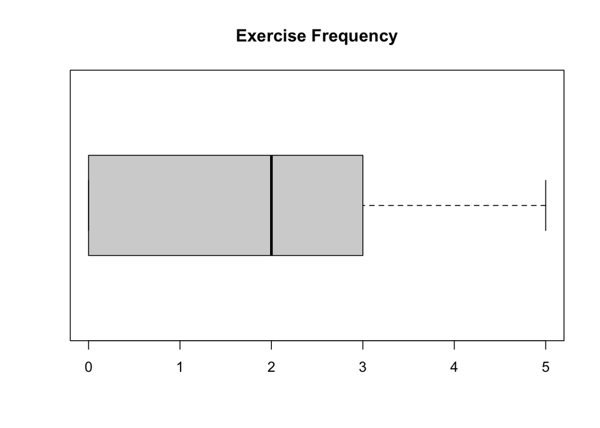

```r
boxplot(cuanti[,7], horizontal = T, main="Exercise Frequency")
```

# 4 Modelo de regresión simple

Nuestro primer modelo será una regresión simple para investigar en qué medida podemos explicar la eficiencia del sueño utilizando una sola variable.

Hicimos la regresión simple con cada una de nuestras variables cuantitativas y la mejor que encontramos fue la siguiente:

```r
modelo1<- lm(Sleep.efficiency~Awakenings)
summary(modelo1)
```

```
##
## Call:
## lm(formula = Sleep.efficiency ~ Awakenings)
##
## Residuals:
##      Min       1Q   Median       3Q      Max
## -0.32441 -0.04520  0.02876  0.07572  0.18610
##
## Coefficients:
##              Estimate Std. Error t value Pr(>|t|)
## (Intercept)  0.881243   0.008849   99.59   <2e-16 ***
## Awakenings  -0.056835   0.004193  -13.55   <2e-16 ***
## ---
## Signif. codes:  0 '***' 0.001 '**' 0.01 '*' 0.05 '.' 0.1 ' ' 1
##
## Residual standard error: 0.1118 on 386 degrees of freedom
## Multiple R-squared:  0.3225, Adjusted R-squared:  0.3207
## F-statistic: 183.7 on 1 and 386 DF,  p-value: < 2.2e-16
```

## 4.1 Diagnóstico del modelo

Buscamos ver que tan bien se acoplan nuestros datos al modelo.

Queremos ver linealidad, pero como se puede observar en las gráficas los datos no son completamente lineales y en la gráfica de Q-Q residuales vemos que en los bordes, los datos se separan mucho de la línea, lo que indica una asimetría en la distribución de los residuos.

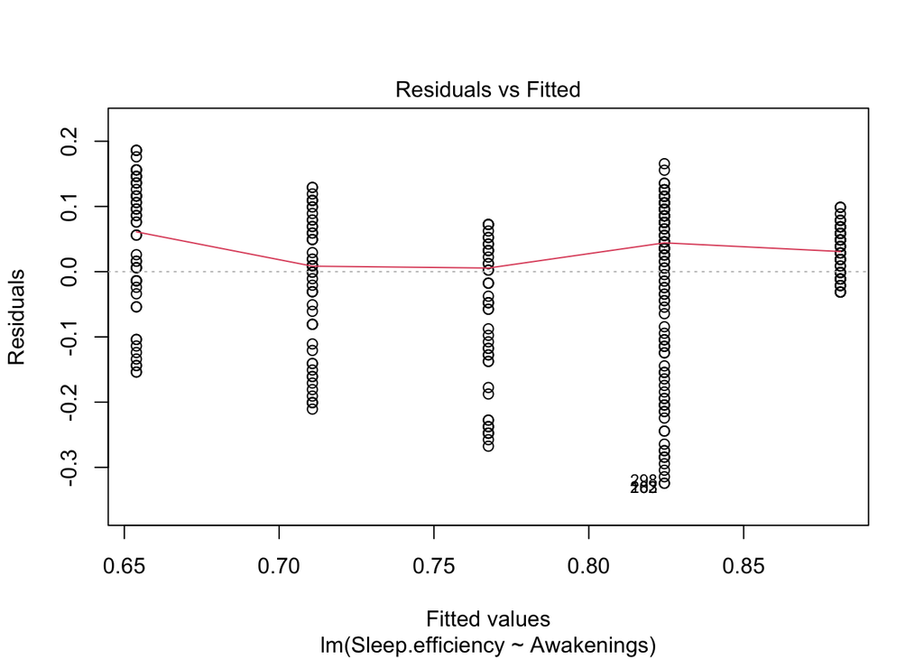

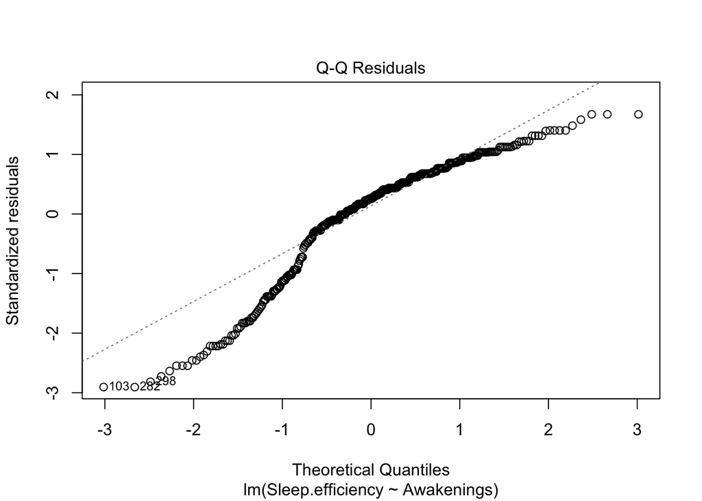

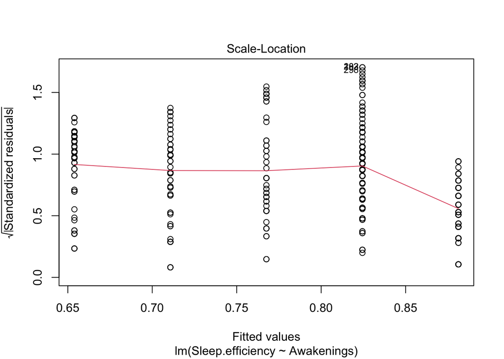

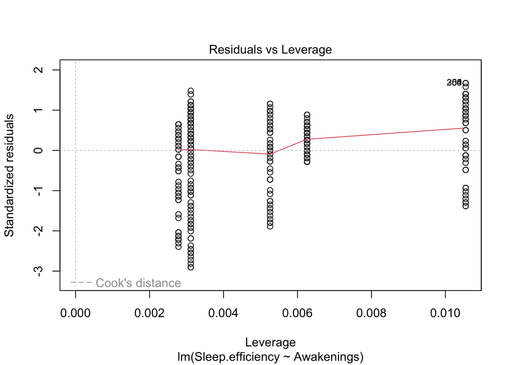

```r
plot(modelo1)
```

# 5 Relación entre las variables

Antes de proponer nuestro modelo múltiple, revisemos la correlación entre todas las variables involucradas.

Aquí podemos ver que no hay mucha correlación entre nuestra variable de estudio Sleep Efficiency y las demás variables cuantitativas, por lo que comenzamos a dudar sobre la relación entre las variables con las que buscamos explicar la eficiencia del sueño y como esto nos afectara en el modelo final.

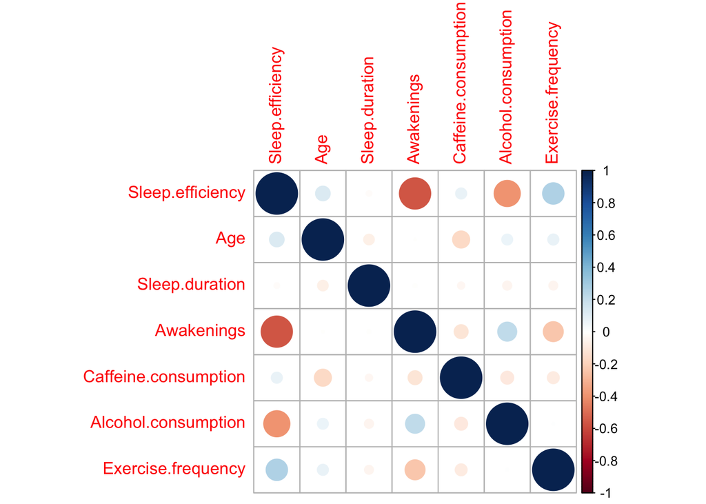

```r
library(corrplot)
corrplot(cor(cuanti))   # correlograma
```

# 6 Modelo de regresión múltiple

## 6.1 Primer modelo de regresión múltiple

Para comenzar haremos un modelo de regresión múltiple que involucre a todas nuestras variables cuantitativas:

```r
modelo1<- lm(Sleep.efficiency~Age+Sleep.duration+Awakenings+Caffeine.consumption+Alcohol.consumption+Exercise.frequency)

modelo1
```

```
##
## Call:
## lm(formula = Sleep.efficiency ~ Age + Sleep.duration + Awakenings +
##     Caffeine.consumption + Alcohol.consumption + Exercise.frequency)
##
## Coefficients:
##          (Intercept)                   Age        Sleep.duration
##            0.8359828             0.0013695            -0.0033306
##           Awakenings  Caffeine.consumption   Alcohol.consumption
##           -0.0465711             0.0001068            -0.0259258
##   Exercise.frequency
##            0.0141422
```

```r
summary(modelo1)
```

```
##
## Call:
## lm(formula = Sleep.efficiency ~ Age + Sleep.duration + Awakenings +
##     Caffeine.consumption + Alcohol.consumption + Exercise.frequency)
##
## Residuals:
##      Min       1Q   Median       3Q      Max
## -0.32587 -0.04616  0.01549  0.06710  0.25480
##
## Coefficients:
##                        Estimate Std. Error t value Pr(>|t|)
## (Intercept)           0.8359828  0.0502874  16.624  < 2e-16 ***
## Age                   0.0013695  0.0003941   3.475 0.000570 ***
## Sleep.duration       -0.0033306  0.0058917  -0.565 0.572202
## Awakenings           -0.0465711  0.0040502 -11.499  < 2e-16 ***
## Caffeine.consumption  0.0001068  0.0001839   0.581 0.561553
## Alcohol.consumption  -0.0259258  0.0033050  -7.844 4.43e-14 ***
## Exercise.frequency    0.0141422  0.0037125   3.809 0.000162 ***
## ---
## Signif. codes:  0 '***' 0.001 '**' 0.01 '*' 0.05 '.' 0.1 ' ' 1
##
## Residual standard error: 0.1018 on 381 degrees of freedom
## Multiple R-squared:  0.4455, Adjusted R-squared:  0.4368
## F-statistic: 51.03 on 6 and 381 DF,  p-value: < 2.2e-16
```

### 6.1.1 Diagnóstico del primer modelo

Podemos ver que el modelo ya nos representa mejor nuestra variable, con una r^2 de 43% y un p-value de 2.2e-16.

Aquí también podemos ver el p-value de cada una de nuestras variables que buscamos que sean menores a .05 En caso de no serlo consideramos que debe de quitarse del modelo.

## 6.2 Gráficas de diagnóstico

Observamos que el modelo mejoro bastante, ahora las gráficas son mucho más lineales, pero esperamos mejorar este modelo al quitar las variables que no respetan el .05 de nuestro valor de riesgo.

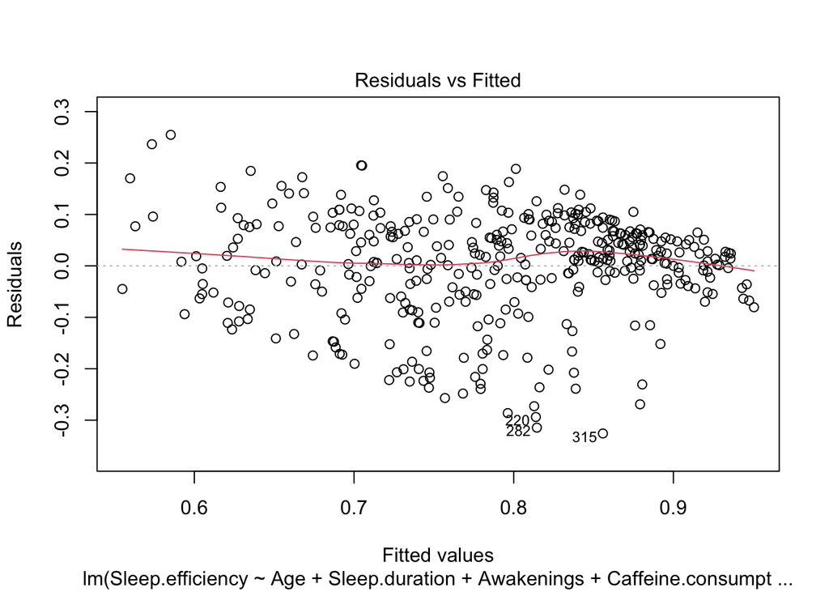

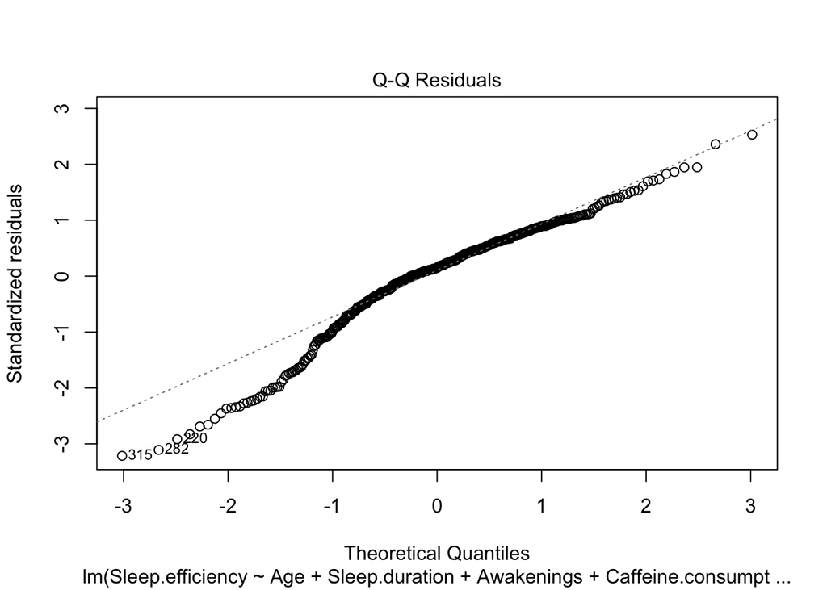

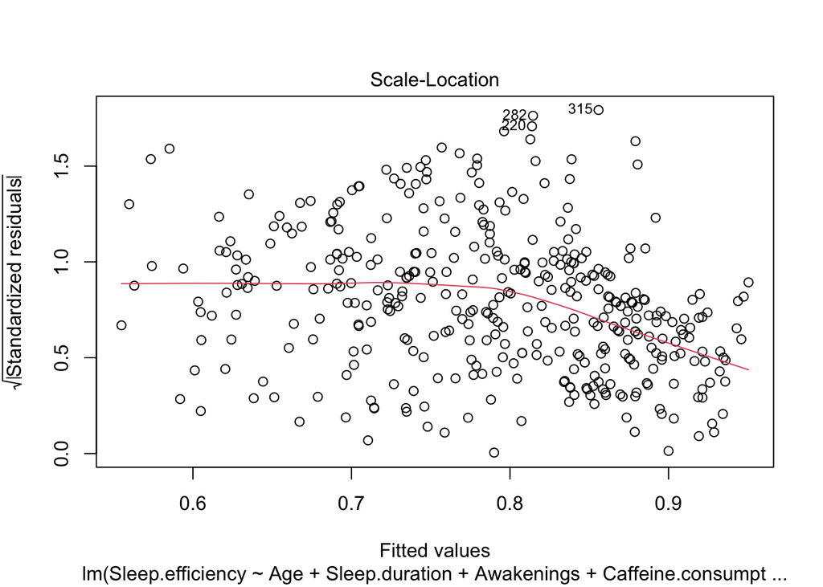

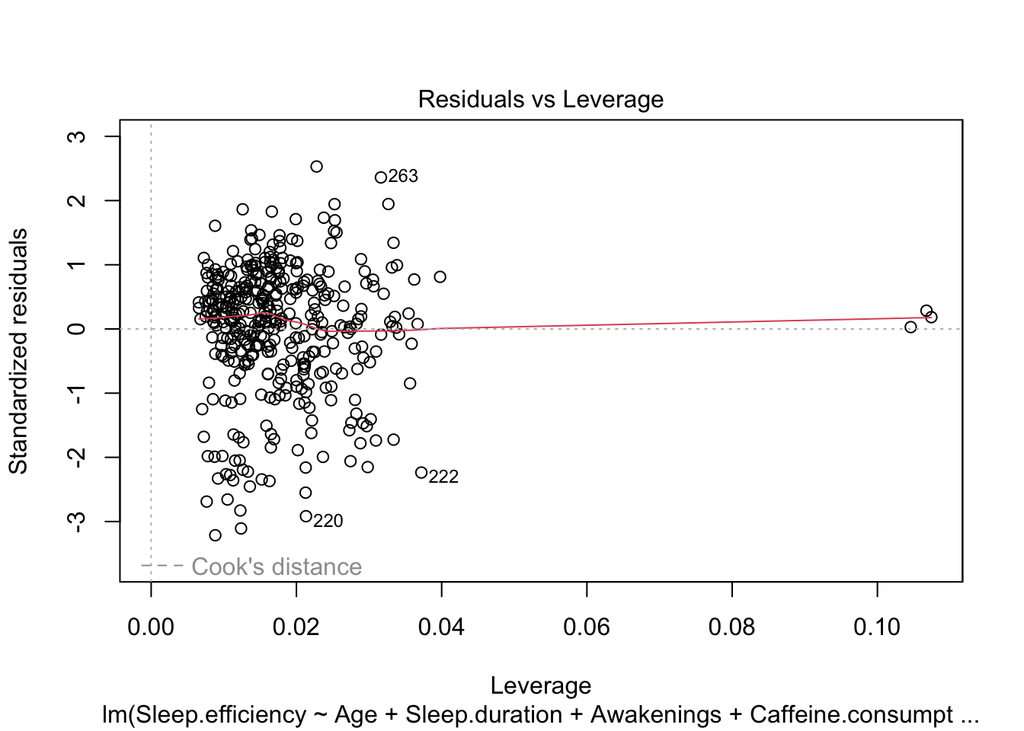

```r
plot(modelo1)
```

## 6.3 Tabla ANOVA

Nos fijamos en la suma de cuadrados de nuestras variables y de los residuales. Lo que esperaremos ver es que la suma de cuadrados de la variable fuera mayor a la de residuos ya que esto indicaría que el factor tiene un efecto significativo en la variable de respuesta.

Como la suma de cuadrados es menor a la de residuos entonces el efecto de nuestras variables en la eficiencia del sueño es baja y la mayoría de la variabilidad se debe a otros factores no incluidos en el modelo.

```r
anova(modelo1)
```

```
## Analysis of Variance Table
##
## Response: Sleep.efficiency
##                       Df Sum Sq Mean Sq  F value    Pr(>F)
## Age                    1 0.1098 0.10975  10.5815 0.0012442 **
## Sleep.duration         1 0.0009 0.00086   0.0832 0.7731545
## Awakenings             1 2.2955 2.29550 221.3184 < 2.2e-16 ***
## Caffeine.consumption   1 0.0053 0.00528   0.5090 0.4760283
## Alcohol.consumption    1 0.6135 0.61348  59.1484 1.261e-13 ***
## Exercise.frequency     1 0.1505 0.15051  14.5116 0.0001623 ***
## Residuals            381 3.9517 0.01037
## ---
## Signif. codes:  0 '***' 0.001 '**' 0.01 '*' 0.05 '.' 0.1 ' ' 1
```

# 7 Selección de variables

Utilizamos step con direccion both para ver que modelos nos devueve R.

```r
step(object = modelo1, direction = "both", trace = 1)
```

```
## Start:  AIC=-1765.7
## Sleep.efficiency ~ Age + Sleep.duration + Awakenings + Caffeine.consumption +
##     Alcohol.consumption + Exercise.frequency
##
##                        Df Sum of Sq    RSS     AIC
## - Sleep.duration        1   0.00331 3.9550 -1767.4
## - Caffeine.consumption  1   0.00350 3.9552 -1767.4
## <none>                              3.9517 -1765.7
## - Age                   1   0.12524 4.0769 -1755.6
## - Exercise.frequency    1   0.15051 4.1022 -1753.2
## - Alcohol.consumption   1   0.63822 4.5899 -1709.6
## - Awakenings            1   1.37135 5.3230 -1652.1
##
## Step:  AIC=-1767.38
## Sleep.efficiency ~ Age + Awakenings + Caffeine.consumption +
##     Alcohol.consumption + Exercise.frequency
##
##                        Df Sum of Sq    RSS     AIC
## - Caffeine.consumption  1   0.00387 3.9589 -1769.0
## <none>                              3.9550 -1767.4
## + Sleep.duration        1   0.00331 3.9517 -1765.7
## - Age                   1   0.12858 4.0836 -1757.0
## - Exercise.frequency    1   0.15305 4.1081 -1754.7
## - Alcohol.consumption   1   0.63541 4.5904 -1711.6
## - Awakenings            1   1.36948 5.3245 -1654.0
##
## Step:  AIC=-1769
## Sleep.efficiency ~ Age + Awakenings + Alcohol.consumption + Exercise.frequency
##
##                        Df Sum of Sq    RSS     AIC
## <none>                              3.9589 -1769.0
## + Caffeine.consumption  1   0.00387 3.9550 -1767.4
## + Sleep.duration        1   0.00369 3.9552 -1767.4
## - Age                   1   0.12473 4.0836 -1759.0
## - Exercise.frequency    1   0.14973 4.1086 -1756.6
## - Alcohol.consumption   1   0.64374 4.6026 -1712.5
## - Awakenings            1   1.40741 5.3663 -1653.0
```

```
##
## Call:
## lm(formula = Sleep.efficiency ~ Age + Awakenings + Alcohol.consumption +
##     Exercise.frequency)
##
## Coefficients:
##         (Intercept)                  Age           Awakenings
##            0.815228             0.001346            -0.046831
## Alcohol.consumption   Exercise.frequency
##           -0.025965             0.014020
```

Lo visualizaremos utilizando R^2 y BIC

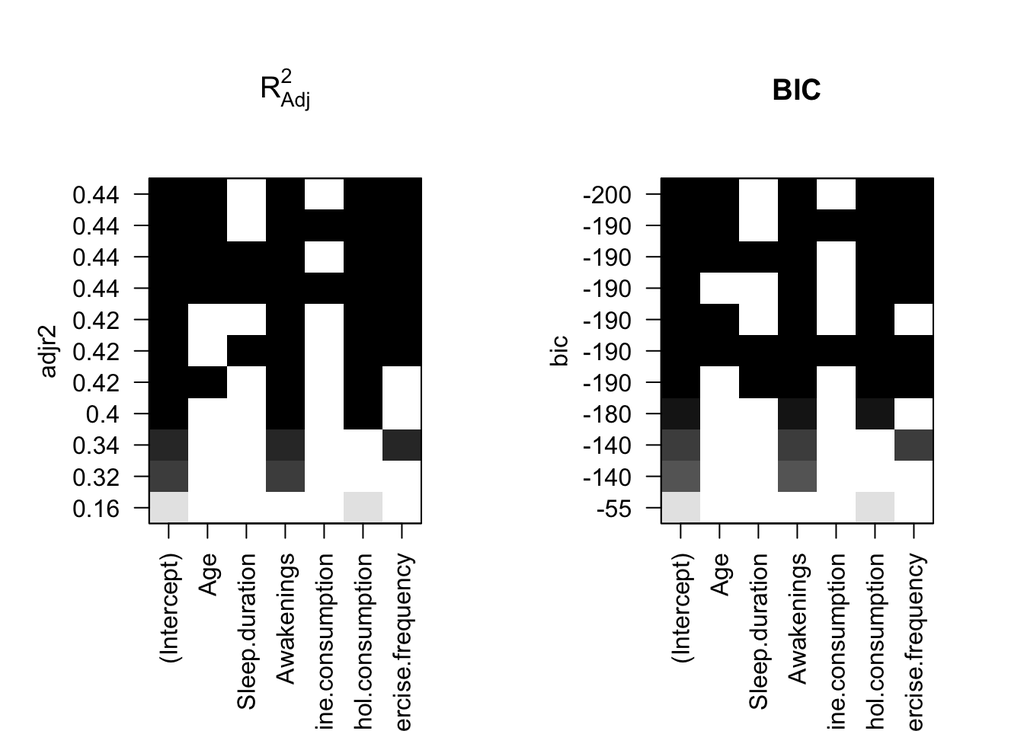

```r
library(leaps)
modelo1_subset <- regsubsets(Sleep.efficiency~Age+Sleep.duration+Awakenings+Caffeine.consumption+Alcohol.consumption+Exercise.frequency, data =datos, nbest=2, nvmax=13)

par(mfrow=c(1, 2))
plot(modelo1_subset, scale="adjr2", main=expression(R[Adj]^2))
plot(modelo1_subset, scale="bic", main="BIC")
```

# 8 Modelo final

Tanto el step como la R^2 y BIC nos devolvieron la misma fórmula (Sleep.efficiency ~ Age + Awakenings + Alcohol.consumption + Exercise.frequency), por lo que será la que utilizaremos para nuestro modelo final.

Podemos ver que el modelo si mejoro, pero muy poco, nuestra R^2 aumento en solo .002 y nuestro valor-p se mantuvo igual.

```r
modelo_f<- lm(Sleep.efficiency ~ Age + Awakenings + Alcohol.consumption + Exercise.frequency)

summary(modelo_f)
```

```
##
## Call:
## lm(formula = Sleep.efficiency ~ Age + Awakenings + Alcohol.consumption +
##     Exercise.frequency)
##
## Residuals:
##      Min       1Q   Median       3Q      Max
## -0.33026 -0.04497  0.01711  0.06660  0.25426
##
## Coefficients:
##                       Estimate Std. Error t value Pr(>|t|)
## (Intercept)          0.8152277  0.0189853  42.940  < 2e-16 ***
## Age                  0.0013461  0.0003875   3.474 0.000572 ***
## Awakenings          -0.0468306  0.0040133 -11.669  < 2e-16 ***
## Alcohol.consumption -0.0259653  0.0032902  -7.892 3.16e-14 ***
## Exercise.frequency   0.0140196  0.0036836   3.806 0.000164 ***
## ---
## Signif. codes:  0 '***' 0.001 '**' 0.01 '*' 0.05 '.' 0.1 ' ' 1
##
## Residual standard error: 0.1017 on 383 degrees of freedom
## Multiple R-squared:  0.4445, Adjusted R-squared:  0.4387
## F-statistic: 76.63 on 4 and 383 DF,  p-value: < 2.2e-16
```

## 8.1 Diagnostico del Modelo Final

En estas graficas podemos ver que los datos se acoplan mejor al modelo, vemos mayor linealidad. Sin embargo el cambio es mínimo en comparación a nuestro primero modelo de regresión múltiple.

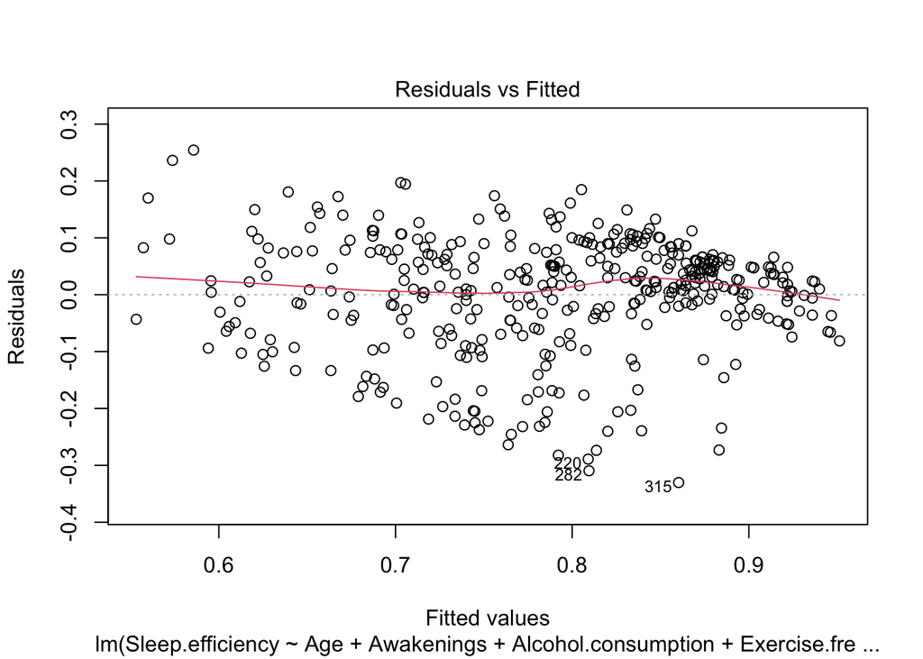

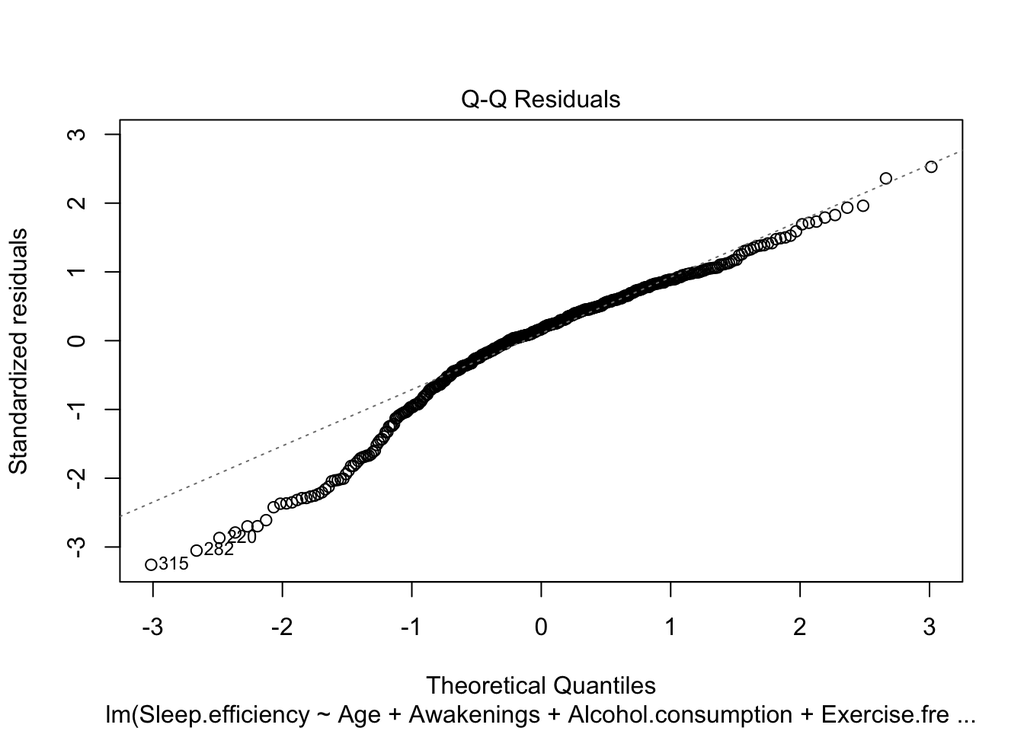

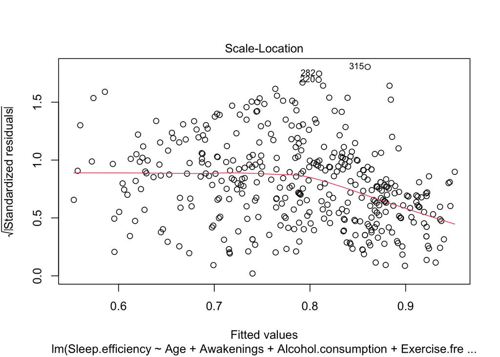

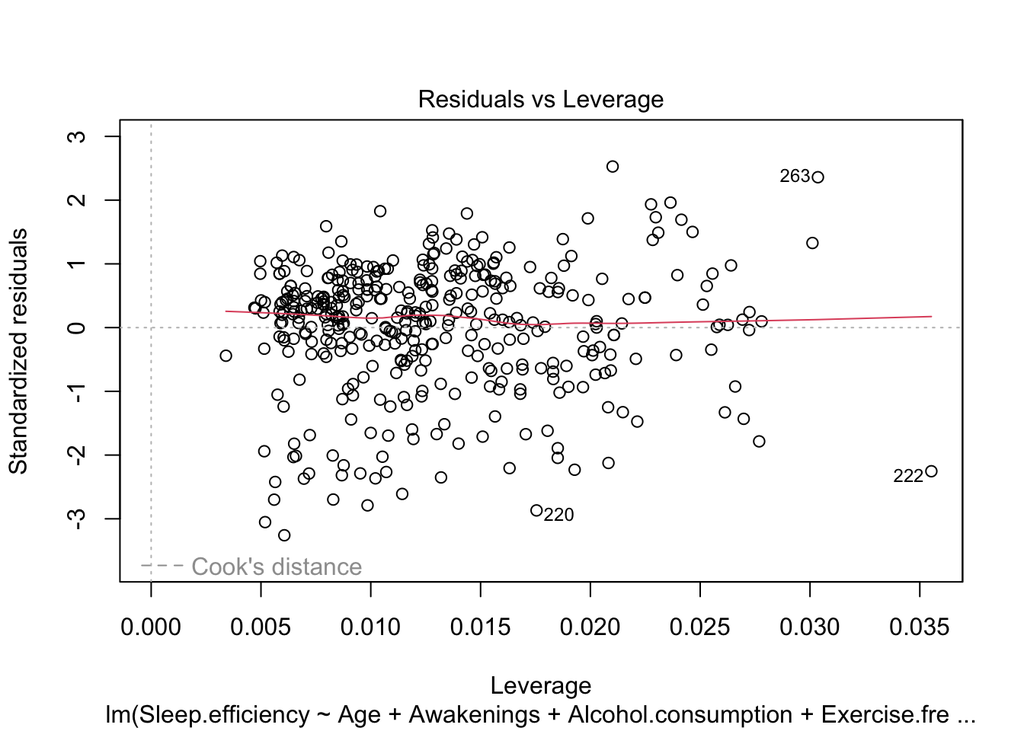

```r
plot(modelo_f)
```

## 8.2 Durbin-Watson

Dado que el valor de Durbin-Watson está cerca de 2 (el valor objetivo), indica que no hay evidencia suficiente para rechazar la hipótesis nula de no autocorrelación. Esto significa que no se ha detectado autocorrelación significativa en los residuos del modelo.

Los resultados indican que no se ha encontrado autocorrelación significativa en los residuos del modelo, lo que sugiere que el modelo no muestra patrones de correlación entre los residuos.

```r
library(car)
durbinWatsonTest(modelo_f)
```

```
##  lag Autocorrelation D-W Statistic p-value
##    1     -0.04999782      2.091054   0.386
##  Alternative hypothesis: rho != 0
```

**CONCLUSIÓN MODELO MÚLTIPLE**

> - Según el valor de $R^2$, el modelo final explica el 43.8% de la variabilidad de la eficiencia de sueño promedio. Así que ha mejorado un poco con respecto al primer modelo múltiple.
> - El modelo final que conseguimos consideramos que no es representativo de la variabilidad de la eficiencia de sueño, tras hacer la selección de variables y la regresión múltiple solo pudimos conseguir explicar un 43.8%. Esto se debe a los datos que utilizamos, las variables utilizadas no son suficientes para explicar de manera significativa la eficiencia de sueño, es decir que hay muchas otras variables que afectan a la eficiencia de sueño.
> - Concluimos que nos hacen falta más datos para poder explicar la eficiencia de sueño.

# 9 Pronóstico

Aunque no consideremos que nuestro modelo sea fiable, se nos pide hacer un pronóstico de datos como se puede ver a continuación:

```r
max(Age)
```

```
## [1] 69
```

```r
max(Awakenings)
```

```
## [1] 4
```

```r
max(Alcohol.consumption)
```

```
## [1] 5
```

```r
max(Exercise.frequency)
```

```
## [1] 5
```

```r
nuevosdatos <- data.frame(Age = c(69,72,75),
                          Awakenings = c(4,7,10),
                          Alcohol.consumption = c(5, 8, 11),
                          Exercise.frequency = c(5,8,11))
```

Las predicciones junto con sus intervalos de predicción:

```r
predict(object=modelo_f, newdata=nuevosdatos, interval = "prediction")
```

```
##         fit        lwr       upr
## 1 0.6610557 0.45646869 0.8656428
## 2 0.4887651 0.27418492 0.7033452
## 3 0.3164744 0.08616781 0.5467810
```